# ProjectWork_RMageddon

Lorenzo Cinelli, Fillippo Novelli, Andrea Goberti, Riccardo Baldini

2025-03-31

# Major League Baseball 1986/1987

This project will analyze the **Hitters** dataset which has information about players in the 1986/1987 season. We will apply a multinomial logistic regression model to predict the salary level of baseball players, given their full set of performance statistics. After so, we will quantify the prediction error using cross-validation approaches and then we will try to identify a better model for this project.

### Usage of ChatGPT

Overall we have used ChatGPT for the visuals, such as histograms, boxplots and the correlation matrix. All this to make sure they were aesthetically pleasing and everything was in place. We also talked with classmates and consulted different accuracy and error rate outputs so to analyze and understand what was going on. ChatGPT was overall very helpful in allowing us to understand what exactly some outputs meant, for example the sensitivity and specificity numbers or the confusion matrix and Kappa values.

Overall ChatGPT was of help in allowing us to understand better the project and certain values, and also helped in creating aesthetically pleasing images for the reader to look at.

## **Multinomial Logistic Regression Model Formalization**

### **Mathematical Representation**

Multinomial logistic regression (MLR) is an extension of binary logistic regression that handles classification problems with more than two categories.

In a generic format, given $K$ possible classes, the probability of class $k$ given input $X$ is:

$$P(Y = k | X) = \frac{\exp(\beta_{k0} + \beta_{k1}X_1 + \beta_{k2}X_2 +
... + \beta_{kp}X_p)}{1 + \sum_{j=1}^{K-1} \exp(\beta_{j0} +
\beta_{j1}X_1 + ... + \beta_{jp}X_p)}$$

for $k = 1, ..., K-1$, where:

- $P(Y = k | X)$ represents the probability of belonging to class $k$ given the predictors $X$.
- $\beta_{k0}$ is the intercept for class $k$.
- $\beta_{ki}$ are the coefficients corresponding to each predictor $X_i$.
- The denominator ensures that all class probabilities sum to 1.

For a **three-class problem** ($K = 3$), the probabilities are:

$$P(Y = \text{Low}) = \frac{1}{1 + e^{f_1(X)} + e^{f_2(X)}}$$

$$P(Y = \text{Medium}) = \frac{e^{f_1(X)}}{1 + e^{f_1(X)} + e^{f_2(X)}}$$

$$P(Y = \text{High}) = \frac{e^{f_2(X)}}{1 + e^{f_1(X)} + e^{f_2(X)}}$$

where:

$$f_1(X) = \beta_{10} + \sum \beta_{1i} X_i$$

$$f_2(X) = \beta_{20} + \sum \beta_{2i} X_i$$

### **Comparison: Multinomial vs. Binary Logistic Regression**

| Feature | **Binary Logistic Regression** | **Multinomial Logistic Regression** |
| --- | --- | --- |
| **Target Variable** | Two classes (e.g., 0 or 1) | More than two classes (e.g., Low, Medium, High) |
| **Formula** | Uses one log-odds function | Uses $K-1$ log-odds functions |
| **Computation** | One equation for one probability | Multiple equations for different categories |
| **Output** | A single probability score | Multiple probabilities summing to 1 |

**Key Differences:** - Binary logistic regression defines a **single decision boundary**, whereas multinomial logistic regression defines **multiple boundaries** to separate more than two categories. - Multinomial logistic regression requires estimating more parameters and is computationally more complex.

#### **Conclusion**

Multinomial logistic regression is useful when the dependent variable has **more than two** possible outcomes. It generalizes binary logistic regression by computing multiple log-odds equations, making it **more flexible** for multi-class classification problems.

## Now let’s start analyzing the data!!!

```r
library(ggplot2)
library(dplyr)
library(corrplot)
library(caret)
library(gridExtra)
library(reshape2)
library(nnet)
Hitters <- read.csv("~/Desktop/Hitters.csv")
```

```r
head(Hitters)
```

```
##   AtBat Hits HmRun Runs RBI Walks Years CAtBat CHits CHmRun CRuns CRBI CWalks
## 1   293   66     1   30  29    14     1    293    66      1    30   29     14
## 2   315   81     7   24  38    39    14   3449   835     69   321  414    375
## 3   479  130    18   66  72    76     3   1624   457     63   224  266    263
## 4   496  141    20   65  78    37    11   5628  1575    225   828  838    354
## 5   321   87    10   39  42    30     2    396   101     12    48   46     33
## 6   594  169     4   74  51    35    11   4408  1133     19   501  336    194
##   League Division PutOuts Assists Errors Salary NewLeague
## 1      A        E     446      33     20     NA         A
## 2      N        W     632      43     10  475.0         N
## 3      A        W     880      82     14  480.0         A
## 4      N        E     200      11      3  500.0         N
## 5      N        E     805      40      4   91.5         N
## 6      A        W     282     421     25  750.0         A
```

```r
str(Hitters)
```

```
## 'data.frame':    317 obs. of  20 variables:
##  $ AtBat    : int  293 315 479 496 321 594 185 298 323 574 ...
##  $ Hits     : int  66 81 130 141 87 169 37 73 81 159 ...
##  $ HmRun    : int  1 7 18 20 10 4 1 0 6 21 ...
##  $ Runs     : int  30 24 66 65 39 74 23 24 26 107 ...
##  $ RBI      : int  29 38 72 78 42 51 8 24 32 75 ...
##  $ Walks    : int  14 39 76 37 30 35 21 7 8 59 ...
##  $ Years    : int  1 14 3 11 2 11 2 3 2 10 ...
##  $ CAtBat   : int  293 3449 1624 5628 396 4408 214 509 341 4631 ...
##  $ CHits    : int  66 835 457 1575 101 1133 42 108 86 1300 ...
##  $ CHmRun   : int  1 69 63 225 12 19 1 0 6 90 ...
##  $ CRuns    : int  30 321 224 828 48 501 30 41 32 702 ...
##  $ CRBI     : int  29 414 266 838 46 336 9 37 34 504 ...
##  $ CWalks   : int  14 375 263 354 33 194 24 12 8 488 ...
##  $ League   : chr  "A" "N" "A" "N" ...
##  $ Division : chr  "E" "W" "W" "E" ...
##  $ PutOuts  : int  446 632 880 200 805 282 76 121 143 238 ...
##  $ Assists  : int  33 43 82 11 40 421 127 283 290 445 ...
##  $ Errors   : int  20 10 14 3 4 25 7 9 19 22 ...
##  $ Salary   : num  NA 475 480 500 91.5 ...
##  $ NewLeague: chr  "A" "N" "A" "N" ...
```

```r
summary(Hitters)
```

```
##      AtBat            Hits           HmRun            Runs
##  Min.   : 16.0   Min.   :  1.0   Min.   : 0.00   Min.   :  0.00
##  1st Qu.:256.0   1st Qu.: 64.0   1st Qu.: 4.00   1st Qu.: 30.00
##  Median :379.0   Median : 96.0   Median : 8.00   Median : 48.00
##  Mean   :381.2   Mean   :101.1   Mean   :10.75   Mean   : 50.89
##  3rd Qu.:512.0   3rd Qu.:137.0   3rd Qu.:16.00   3rd Qu.: 69.00
##  Max.   :687.0   Max.   :238.0   Max.   :40.00   Max.   :130.00
##
##       RBI             Walks            Years            CAtBat
##  Min.   :  0.00   Min.   :  0.00   Min.   : 1.000   Min.   :   19
##  1st Qu.: 28.00   1st Qu.: 22.00   1st Qu.: 4.000   1st Qu.:  822
##  Median : 44.00   Median : 35.00   Median : 6.000   Median : 1928
##  Mean   : 47.95   Mean   : 38.51   Mean   : 7.429   Mean   : 2646
##  3rd Qu.: 63.00   3rd Qu.: 53.00   3rd Qu.:11.000   3rd Qu.: 3919
##  Max.   :121.00   Max.   :105.00   Max.   :24.000   Max.   :14053
##
##      CHits            CHmRun           CRuns             CRBI
##  Min.   :   4.0   Min.   :  0.00   Min.   :   1.0   Min.   :   0.0
##  1st Qu.: 209.0   1st Qu.: 14.00   1st Qu.: 101.0   1st Qu.:  91.0
##  Median : 506.0   Median : 37.00   Median : 247.0   Median : 219.0
##  Mean   : 717.3   Mean   : 68.94   Mean   : 358.1   Mean   : 328.8
##  3rd Qu.:1051.0   3rd Qu.: 90.00   3rd Qu.: 518.0   3rd Qu.: 421.0
##  Max.   :4256.0   Max.   :548.00   Max.   :2165.0   Max.   :1659.0
##
##      CWalks        League            Division            PutOuts
##  Min.   :   0   Length:317         Length:317         Min.   :   0.0
##  1st Qu.:  68   Class :character   Class :character   1st Qu.: 109.0
##  Median : 170   Mode  :character   Mode  :character   Median : 212.0
##  Mean   : 258                                         Mean   : 290.5
##  3rd Qu.: 337                                         3rd Qu.: 325.0
##  Max.   :1566                                         Max.   :1378.0
##
##     Assists          Errors           Salary        NewLeague
##  Min.   :  0.0   Min.   : 0.000   Min.   :  67.5   Length:317
##  1st Qu.:  7.0   1st Qu.: 3.000   1st Qu.: 190.0   Class :character
##  Median : 40.0   Median : 6.000   Median : 420.0   Mode  :character
##  Mean   :107.9   Mean   : 8.091   Mean   : 532.8
##  3rd Qu.:166.0   3rd Qu.:11.000   3rd Qu.: 750.0
##  Max.   :492.0   Max.   :32.000   Max.   :2460.0
##                                   NA's   :58
```

## Main Findings

From this initial analysis of the CSV given, we have the following conclusions; The dataset contains 317 rows and 20 columns. It is broken down like so:

- Player Performance (Per Season)
  - AtBat, Hits, HmRun, Runs, RBI, Walks → These represent a player’s performance.
- Career Statistics
  - CAtBat, CHits, CHmRun, CRuns, CRBI, CWalks → These are cumulative career stats.
- Defensive Stats
  - PutOuts, Assists, Errors → Fielding performance.
- Experience
  - Years → Number of years played in the Major League.
- **Categorical Variables**
  - League (A/N), Division (E/W), NewLeague (A/N).
- Target Variable
  - *Salary* → The player’s salary (in $1000s), but 58 values are missing.

```r
# Check for missing values
colSums(is.na(Hitters))
```

```
##     AtBat      Hits     HmRun      Runs       RBI     Walks     Years    CAtBat
##         0         0         0         0         0         0         0         0
##     CHits    CHmRun     CRuns      CRBI    CWalks    League  Division   PutOuts
##         0         0         0         0         0         0         0         0
##   Assists    Errors    Salary NewLeague
##         0         0        58         0
```

```r
# Remove rows with missing Salary values
Hitters_cleaned <- na.omit(Hitters)


sum(is.na(Hitters_cleaned$Salary))
```

```
## [1] 0
```

```r
#now lets see if the colSums are all 0's
colSums(is.na(Hitters_cleaned))
```

```
##     AtBat      Hits     HmRun      Runs       RBI     Walks     Years    CAtBat
##         0         0         0         0         0         0         0         0
##     CHits    CHmRun     CRuns      CRBI    CWalks    League  Division   PutOuts
##         0         0         0         0         0         0         0         0
##   Assists    Errors    Salary NewLeague
##         0         0         0         0
```

The missing values were really important to get rid of because it could heavily affect the functionality of this analysis:

- Missing salary values would disrupt model training (since it’s our target variable).
- Instead of mean imputation which probably would have introduced bias, we remove the missing values to keep the dataset clean.
- We will now provide a more visual and in depth reasoning as to *why* we got rid of the missing values instead of doing some imputation.

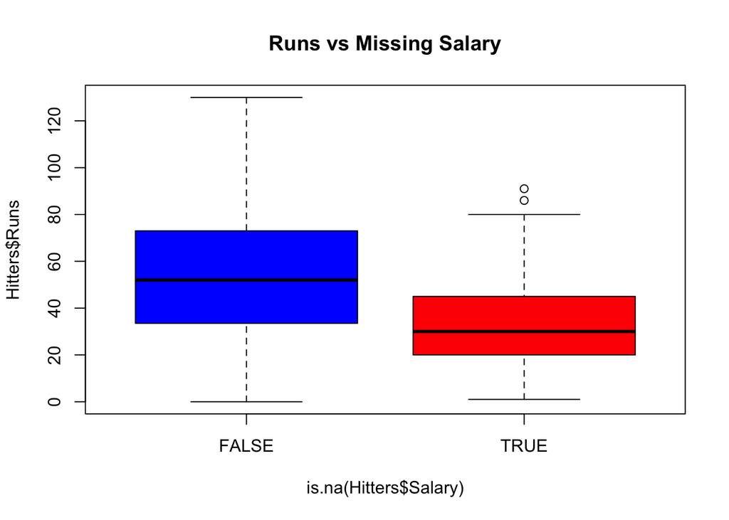

```r
boxplot(Hitters$Runs ~ is.na(Hitters$Salary), main="Runs vs Missing Salary", col=c("blue", "red"))
```

There is a clear trend showing that players with missing salary data tend to have lower offensive performance (Runs). This suggests that missing salary values may not be random—they’re likely associated with lower performance, and possibly less media or league attention. But…… we are going to run some t-tests to make sure that what we are seeing is actually true🧐🧐🧐

```r
t_crbi   <- t.test(Hitters$CRBI ~ is.na(Hitters$Salary))
t_cruns  <- t.test(Hitters$CRuns ~ is.na(Hitters$Salary))
t_catbat <- t.test(Hitters$CAtBat ~ is.na(Hitters$Salary))
t_chmrun <- t.test(Hitters$CHmRun ~ is.na(Hitters$Salary))
t_years  <- t.test(Hitters$Years ~ is.na(Hitters$Salary))
t_rbi  <- t.test(Hitters$RBI ~ is.na(Hitters$Salary))


p_values_new <- data.frame(
  Variable = c("CRBI", "CRuns", "CAtBat", "CHmRun", "Years", "RBI"),
  P_Value = c(t_crbi$p.value, t_cruns$p.value, t_catbat$p.value, t_chmrun$p.value, t_years$p.value, t_rbi$p.value)
)


p_values_new$Significant <- ifelse(p_values_new$P_Value < 0.05, "Yes", "No")


print(p_values_new)
```

```
##   Variable      P_Value Significant
## 1     CRBI 9.017865e-01          No
## 2    CRuns 9.084075e-01          No
## 3   CAtBat 9.897045e-01          No
## 4   CHmRun 8.099601e-01          No
## 5    Years 2.551936e-01          No
## 6      RBI 1.818583e-07         Yes
```

- RBI is the only significant predictor of missing salary among the tested variables. Players with missing salary data are likely to differ in RBI from those with reported salary—possibly performing worse.
- Other variables like career runs, home runs, at-bats, and years of experience do not significantly differ, meaning missingness in salary is not strongly associated with those metrics.
- RBI might be an underlying driver or proxy for salary visibility, but it could also be the only one to differ in the entire dataset.

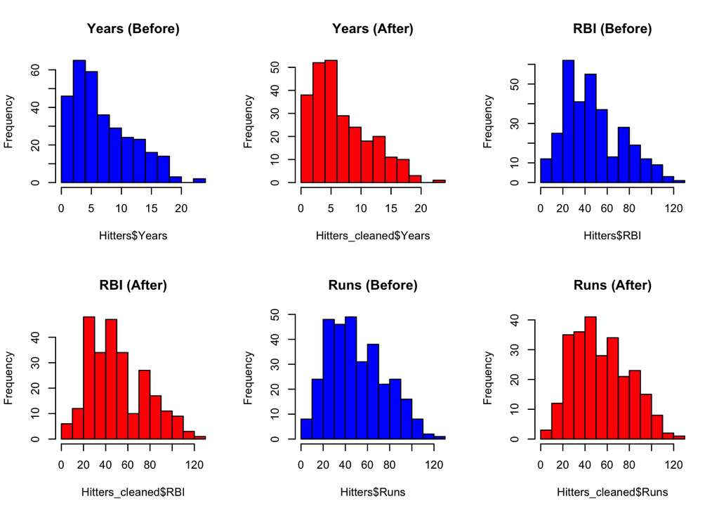

```r
par(mfrow=c(2,3))

hist(Hitters$Years, main="Years (Before)", col="blue", breaks=10)
hist(Hitters_cleaned$Years, main="Years (After)", col="red", breaks=10)

hist(Hitters$RBI, main="RBI (Before)", col="blue", breaks=10)
hist(Hitters_cleaned$RBI, main="RBI (After)", col="red", breaks=10)

hist(Hitters$Runs, main="Runs (Before)", col="blue", breaks=10)
hist(Hitters_cleaned$Runs, main="Runs (After)", col="red", breaks=10)
```

### Why We Removed Rows with NA Salary Values

- **Focused Removal**:
  - Only rows with missing (NA) Salary were removed for the following reasons
- **Minimal Impact on Data Integrity**:
  - Only RBI showed a statistically significant difference between players with and without missing salary values and even that difference was not as bad as we had thought, seen by the histograms above. While the other key variables had distributions remain the same basically.
  - This suggests the removal had little to no impact on the overall structure of the dataset.😱
- **Avoids Data Leakage**:
  - Imputing Salary using variables that are later used to predict SalaryLevel could risk leaking target information into the model which is not good because otherwise the whole point of the project is ruined.
  - By removing only the NA salary rows, we ensure the model is trained on *clean*, unbiased data.
- **Simplifies Workflow**:
  - Reduces complexity by avoiding imputation.
  - Keeps the data pipeline clean, transparent, and reproducible.
- **Preserves Representativeness**:
  - The remaining dataset (after dropping NA salaries) is still balanced and representative so it can be used.

## Pre-Processing

#### Now we have to convert categorical variables into factors. Why?

*Because machine learning models require categorical variables in factor format, it ensures that R treats them correctly while modeling the data*.

```r
Hitters_cleaned <- Hitters_cleaned %>%
  mutate(across(c(League, Division, NewLeague), as.factor))
str(Hitters_cleaned)
```

```
## 'data.frame':    259 obs. of  20 variables:
##  $ AtBat    : int  315 479 496 321 594 185 298 323 574 202 ...
##  $ Hits     : int  81 130 141 87 169 37 73 81 159 53 ...
##  $ HmRun    : int  7 18 20 10 4 1 0 6 21 4 ...
##  $ Runs     : int  24 66 65 39 74 23 24 26 107 31 ...
##  $ RBI      : int  38 72 78 42 51 8 24 32 75 26 ...
##  $ Walks    : int  39 76 37 30 35 21 7 8 59 27 ...
##  $ Years    : int  14 3 11 2 11 2 3 2 10 9 ...
##  $ CAtBat   : int  3449 1624 5628 396 4408 214 509 341 4631 1876 ...
##  $ CHits    : int  835 457 1575 101 1133 42 108 86 1300 467 ...
##  $ CHmRun   : int  69 63 225 12 19 1 0 6 90 15 ...
##  $ CRuns    : int  321 224 828 48 501 30 41 32 702 192 ...
##  $ CRBI     : int  414 266 838 46 336 9 37 34 504 186 ...
##  $ CWalks   : int  375 263 354 33 194 24 12 8 488 161 ...
##  $ League   : Factor w/ 2 levels "A","N": 2 1 2 2 1 2 1 2 1 2 ...
##  $ Division : Factor w/ 2 levels "E","W": 2 2 1 1 2 1 2 2 1 2 ...
##  $ PutOuts  : int  632 880 200 805 282 76 121 143 238 304 ...
##  $ Assists  : int  43 82 11 40 421 127 283 290 445 45 ...
##  $ Errors   : int  10 14 3 4 25 7 9 19 22 11 ...
##  $ Salary   : num  475 480 500 91.5 750 ...
##  $ NewLeague: Factor w/ 2 levels "A","N": 2 1 2 2 1 1 1 2 1 2 ...
##  - attr(*, "na.action")= 'omit' Named int [1:58] 1 15 18 21 28 30 34 36 38 39 ...
##   ..- attr(*, "names")= chr [1:58] "1" "15" "18" "21" ...
```

### Feature Engineering –> Salary Binning For classification

Since we are using **multinomial logistic regression**, we must convert the numerical Salary variable into categories:

- Since we are performing classification, not regression, we need a categorical target.
- We bin Salary into 5 groups using quantiles to ensure balanced classes.
- Before we will illustrate how using other methods such as k-means can give very unbalanced data which is not something we need.

```r
Hitters_cleaned <- na.omit(Hitters)
set.seed(123)
clusters <- kmeans(Hitters_cleaned$Salary, centers = 5)$cluster
Hitters_cleaned$SalaryLevel <- factor(clusters, labels = c("Group1", "Group2", "Group3", "Group4", "Group5"))
table(Hitters_cleaned$SalaryLevel)
```

```
##
## Group1 Group2 Group3 Group4 Group5
##     10     67    107     15     60
```

As you can see the distribution is almost laughable😂… We have to fix this–> **How**? With quantile based salary levels.

```r
# Create quantile-based salary levels
Hitters_cleaned <- na.omit(Hitters)
Hitters_cleaned$SalaryLevel <- cut(Hitters_cleaned$Salary,
                           breaks = quantile(Hitters_cleaned$Salary, probs = seq(0, 1, length.out = 6), na.rm = TRUE),
                           include.lowest = TRUE,
                           labels = c("Group1", "Group2", "Group3", "Group4", "Group5"))
print(Hitters_cleaned$SalaryLevel)
```

```
##   [1] Group3 Group3 Group3 Group1 Group4 Group1 Group1 Group1 Group3 Group3
##  [11] Group4 Group4 Group2 Group4 Group2 Group1 Group1 Group4 Group4 Group4
##  [21] Group4 Group4 Group4 Group1 Group4 Group2 Group5 Group1 Group1 Group2
##  [31] Group3 Group2 Group2 Group5 Group1 Group5 Group4 Group3 Group3 Group3
##  [41] Group5 Group1 Group2 Group2 Group2 Group5 Group1 Group1 Group3 Group5
##  [51] Group4 Group5 Group5 Group2 Group3 Group2 Group3 Group5 Group5 Group4
##  [61] Group5 Group1 Group2 Group3 Group3 Group5 Group1 Group1 Group4 Group5
##  [71] Group2 Group3 Group5 Group3 Group4 Group5 Group1 Group5 Group3 Group5
##  [81] Group2 Group5 Group1 Group4 Group4 Group3 Group4 Group2 Group3 Group3
##  [91] Group4 Group3 Group4 Group4 Group5 Group4 Group2 Group3 Group1 Group2
## [101] Group1 Group5 Group3 Group1 Group2 Group2 Group5 Group4 Group5 Group2
## [111] Group4 Group5 Group3 Group1 Group1 Group1 Group2 Group1 Group4 Group2
## [121] Group4 Group1 Group5 Group2 Group1 Group4 Group2 Group1 Group5 Group2
## [131] Group3 Group4 Group1 Group5 Group5 Group5 Group5 Group4 Group4 Group1
## [141] Group5 Group4 Group2 Group3 Group1 Group5 Group2 Group2 Group3 Group2
## [151] Group4 Group5 Group4 Group1 Group3 Group1 Group4 Group4 Group1 Group1
## [161] Group4 Group4 Group4 Group1 Group1 Group4 Group2 Group1 Group5 Group5
## [171] Group1 Group1 Group2 Group5 Group2 Group3 Group2 Group2 Group5 Group4
## [181] Group4 Group3 Group2 Group5 Group4 Group2 Group4 Group1 Group3 Group2
## [191] Group2 Group5 Group2 Group3 Group4 Group5 Group3 Group3 Group3 Group2
## [201] Group3 Group3 Group4 Group1 Group5 Group2 Group2 Group4 Group2 Group1
## [211] Group1 Group4 Group1 Group3 Group5 Group1 Group1 Group2 Group1 Group1
## [221] Group3 Group5 Group1 Group1 Group3 Group1 Group3 Group3 Group5 Group3
## [231] Group3 Group2 Group4 Group3 Group5 Group2 Group5 Group2 Group2 Group2
## [241] Group5 Group2 Group3 Group5 Group3 Group2 Group4 Group2 Group5 Group3
## [251] Group4 Group5 Group1 Group2 Group4 Group5 Group3 Group5 Group5
## Levels: Group1 Group2 Group3 Group4 Group5
```

```r
table(Hitters_cleaned$SalaryLevel)
```

```
##
## Group1 Group2 Group3 Group4 Group5
##     53     53     49     52     52
```

Now thats more like it, we have a more balanced dataset!! Now lets make a table to show the boundaries for each group

```r
breaks <- quantile(Hitters_cleaned$Salary, probs = seq(0, 1, length.out = 6), na.rm = TRUE)
group_ranges <- data.frame(
  Group = paste0("Group", 1:5),
  Lower_Bound = head(breaks, -1),
  Upper_Bound = tail(breaks, -1)
)

print(group_ranges)
```

```
##      Group Lower_Bound Upper_Bound
## 0%  Group1        67.5       155.0
## 20% Group2       155.0       300.0
## 40% Group3       300.0       534.0
## 60% Group4       534.0       792.5
## 80% Group5       792.5      2460.0
```

# EDA

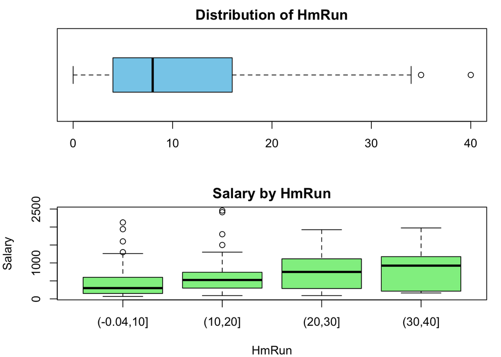

```r
plot_variable_with_salary <- function(varname, bins = 4) {
  var <- Hitters[[varname]]


  if (length(unique(var)) > 10) {
    var_binned <- cut(var, bins)
  } else {
    var_binned <- factor(var)
  }

  par(mfrow = c(2, 1), mar=c(4,4,2,1))


  boxplot(var, col = "skyblue", horizontal = TRUE,
          main = paste("Distribution of", varname))


  boxplot(Salary ~ var_binned, data = Hitters,
          col = "lightgreen",
          main = paste("Salary by", varname),
          xlab = varname, ylab = "Salary")

  par(mfrow = c(1, 1))
}


plot_variable_with_salary("HmRun")
```

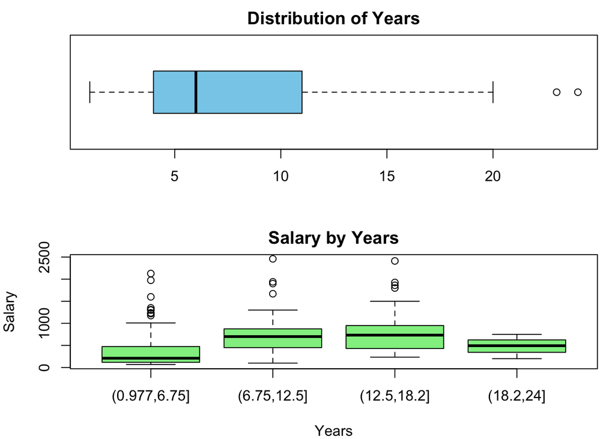

```r
plot_variable_with_salary("Years")
```

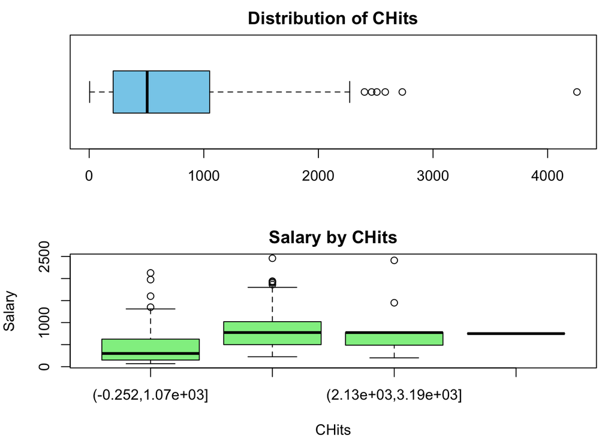

```r
plot_variable_with_salary("CHits")
```

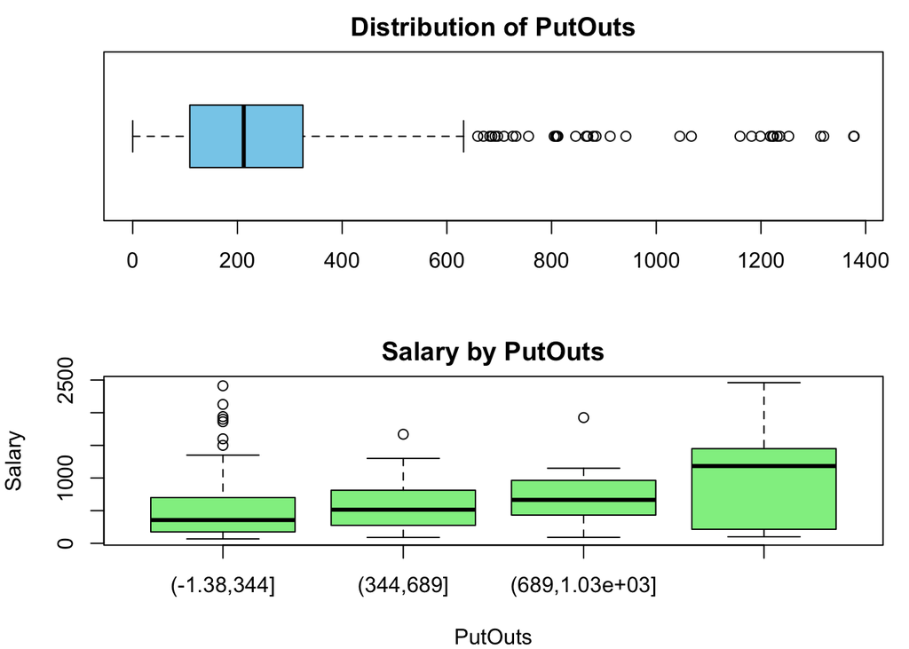

```r
plot_variable_with_salary("PutOuts")
```